# Project: Investigate a Dataset - [No-show appointments]

- Introduction
- Data Wrangling
- Data Cleaning
- Exploratory Data Analysis
- Conclusions

## Introduction

### Dataset Description

> This dataset collects information from 100k medical appointments in Brazil and is focused on the question of whether or not patients show up for their appointment. ● ‘ScheduledDay’ tells us on what day the patient booked their appointment.The ‘Neighborhood’ indicates the location of the hospital. ‘Scholarship’ indicates whether or not the patient is enrolled in Brasilian welfare program Bolsa Família. The last column of the dataset indicates ‘No’ if the patient showed up to their appointment, and ‘Yes’ if they did not show up

### Question(s) for Analysis

> Question1: Total number of appointment based on Neighbourhood?

> Question2: What kind medical condition that had the highest appointment Show up?

> Question3: What kind medical condition that had the highest appointment No Show up?

> Question4: What gender had the most show up?

> Question5: What Gender did not show up for appointments?

```python
import pandas as pd
import seaborn as sns
import matplotlib.pyplot as plt
import numpy as np

%matplotlib inline
```

## Data Wrangling

> Loading the data and print out a few lines. Perform operations to inspect data types, shape, info and look for instances of missing /possibly errant data or duplicated data

```python
df=pd.read_csv('noshowappointments-kagglev2-may-2016.csv')

df.head()
```

|  | PatientId | AppointmentID | Gender | ScheduledDay | AppointmentDay | Age | Neighbourhood | Scholarship | Hipertension | Diabetes | Alcoholism | Handcap | SMS_received | No-show |
| --- | --- | --- | --- | --- | --- | --- | --- | --- | --- | --- | --- | --- | --- | --- |
| 0 | 2.987250e+13 | 5642903 | F | 2016-04-29T18:38:08Z | 2016-04-29T00:00:00Z | 62 | JARDIM DA PENHA | 0 | 1 | 0 | 0 | 0 | 0 | No |
| 1 | 5.589978e+14 | 5642503 | M | 2016-04-29T16:08:27Z | 2016-04-29T00:00:00Z | 56 | JARDIM DA PENHA | 0 | 0 | 0 | 0 | 0 | 0 | No |
| 2 | 4.262962e+12 | 5642549 | F | 2016-04-29T16:19:04Z | 2016-04-29T00:00:00Z | 62 | MATA DA PRAIA | 0 | 0 | 0 | 0 | 0 | 0 | No |
| 3 | 8.679512e+11 | 5642828 | F | 2016-04-29T17:29:31Z | 2016-04-29T00:00:00Z | 8 | PONTAL DE CAMBURI | 0 | 0 | 0 | 0 | 0 | 0 | No |
| 4 | 8.841186e+12 | 5642494 | F | 2016-04-29T16:07:23Z | 2016-04-29T00:00:00Z | 56 | JARDIM DA PENHA | 0 | 1 | 1 | 0 | 0 | 0 | No |

```python
#  Number of rows and columns
df.shape
```

```
(110527, 14)
```

```python
# Checking which columns that have missing values

df.info()
```

```
<class 'pandas.core.frame.DataFrame'>
RangeIndex: 110527 entries, 0 to 110526
Data columns (total 14 columns):
PatientId         110527 non-null float64
AppointmentID     110527 non-null int64
Gender            110527 non-null object
ScheduledDay      110527 non-null object
AppointmentDay    110527 non-null object
Age               110527 non-null int64
Neighbourhood     110527 non-null object
Scholarship       110527 non-null int64
Hipertension      110527 non-null int64
Diabetes          110527 non-null int64
Alcoholism        110527 non-null int64
Handcap           110527 non-null int64
SMS_received      110527 non-null int64
No-show           110527 non-null object
dtypes: float64(1), int64(8), object(5)
memory usage: 11.8+ MB
```

```python
#  Checking for duplicate entry vallues in datasets
df.duplicated().sum()
```

```
0
```

```python
# To find correlation in the datasets
df.corr()
```

|  | PatientId | AppointmentID | Age | Scholarship | Hipertension | Diabetes | Alcoholism | Handcap | SMS_received |
| --- | --- | --- | --- | --- | --- | --- | --- | --- | --- |
| PatientId | 1.000000 | 0.004039 | -0.004139 | -0.002880 | -0.006441 | 0.001605 | 0.011011 | -0.007916 | -0.009749 |
| AppointmentID | 0.004039 | 1.000000 | -0.019126 | 0.022615 | 0.012752 | 0.022628 | 0.032944 | 0.014106 | -0.256618 |
| Age | -0.004139 | -0.019126 | 1.000000 | -0.092457 | 0.504586 | 0.292391 | 0.095811 | 0.078033 | 0.012643 |
| Scholarship | -0.002880 | 0.022615 | -0.092457 | 1.000000 | -0.019729 | -0.024894 | 0.035022 | -0.008586 | 0.001194 |
| Hipertension | -0.006441 | 0.012752 | 0.504586 | -0.019729 | 1.000000 | 0.433086 | 0.087971 | 0.080083 | -0.006267 |
| Diabetes | 0.001605 | 0.022628 | 0.292391 | -0.024894 | 0.433086 | 1.000000 | 0.018474 | 0.057530 | -0.014550 |
| Alcoholism | 0.011011 | 0.032944 | 0.095811 | 0.035022 | 0.087971 | 0.018474 | 1.000000 | 0.004648 | -0.026147 |
| Handcap | -0.007916 | 0.014106 | 0.078033 | -0.008586 | 0.080083 | 0.057530 | 0.004648 | 1.000000 | -0.024161 |
| SMS_received | -0.009749 | -0.256618 | 0.012643 | 0.001194 | -0.006267 | -0.014550 | -0.026147 | -0.024161 | 1.000000 |

## Conclusion on Data wrangling

> **Conclusion:** The dataset had total of **110527** number of rows or entries and **14** total number of columns with no missing data values, there is no duplicate values in the dataset.

# Data Cleaning

```python
# droping appointmentday bcos its same as schelduled day

df_a = df.drop('AppointmentDay', axis=1)
```

```python
#  changing the format of ScheduledDay dtype to date format
df_a['ScheduledDay']= pd.to_datetime(df_a['ScheduledDay'].str.strip())
df_a['ScheduledDay']= pd.to_datetime(df_a['ScheduledDay'].dt.date)
```

```python
df_a.info()
```

```
<class 'pandas.core.frame.DataFrame'>
RangeIndex: 110527 entries, 0 to 110526
Data columns (total 13 columns):
PatientId        110527 non-null float64
AppointmentID    110527 non-null int64
Gender           110527 non-null object
ScheduledDay     110527 non-null datetime64[ns]
Age              110527 non-null int64
Neighbourhood    110527 non-null object
Scholarship      110527 non-null int64
Hipertension     110527 non-null int64
Diabetes         110527 non-null int64
Alcoholism       110527 non-null int64
Handcap          110527 non-null int64
SMS_received     110527 non-null int64
No-show          110527 non-null object
dtypes: datetime64[ns](1), float64(1), int64(8), object(3)
memory usage: 11.0+ MB
```

```python
#  Renaming columns with spelling mistakes : Hipertension to Hypertension, Handcap to Handicap
df_a=df_a.rename(columns={'Hipertension':'Hypertension',
                   'Handcap':'Handicap'})
```

## Exploratory Data Analysis

>

### Research Question 1 Total number of appointment based on Neighbourhood

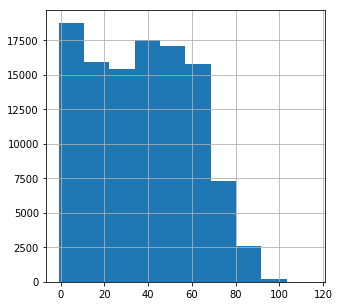

```python
# Distribution of comment
df_a.Age.hist(figsize=(5,5));
```

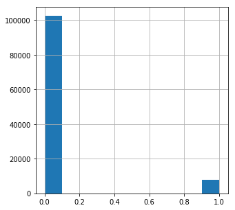

```python
df_a.Diabetes.hist(figsize=(5,5));
```

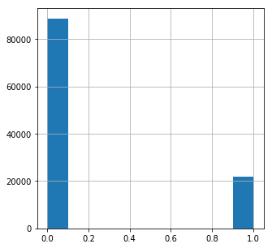

```python
df_a.Hypertension.hist(figsize=(5,5));
```

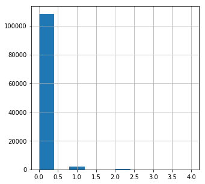

```python
df_a.Handicap.hist(figsize=(5,5));
```

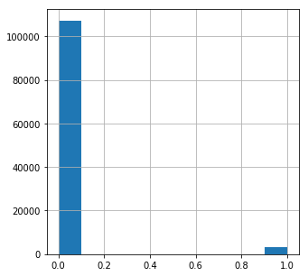

```python
df_a.Alcoholism.hist(figsize=(5,5));
```

```python
df_a.head()
```

|  | PatientId | AppointmentID | Gender | ScheduledDay | Age | Neighbourhood | Scholarship | Hypertension | Diabetes | Alcoholism | Handicap | SMS_received | No-show |
| --- | --- | --- | --- | --- | --- | --- | --- | --- | --- | --- | --- | --- | --- |
| 0 | 2.987250e+13 | 5642903 | F | 2016-04-29 | 62 | JARDIM DA PENHA | 0 | 1 | 0 | 0 | 0 | 0 | No |
| 1 | 5.589978e+14 | 5642503 | M | 2016-04-29 | 56 | JARDIM DA PENHA | 0 | 0 | 0 | 0 | 0 | 0 | No |
| 2 | 4.262962e+12 | 5642549 | F | 2016-04-29 | 62 | MATA DA PRAIA | 0 | 0 | 0 | 0 | 0 | 0 | No |
| 3 | 8.679512e+11 | 5642828 | F | 2016-04-29 | 8 | PONTAL DE CAMBURI | 0 | 0 | 0 | 0 | 0 | 0 | No |
| 4 | 8.841186e+12 | 5642494 | F | 2016-04-29 | 56 | JARDIM DA PENHA | 0 | 1 | 1 | 0 | 0 | 0 | No |

```python
def label(x,y,t):

    plt.xlabel(x)
    plt.ylabel(y)
    plt.title(t)
    plt.show()
```

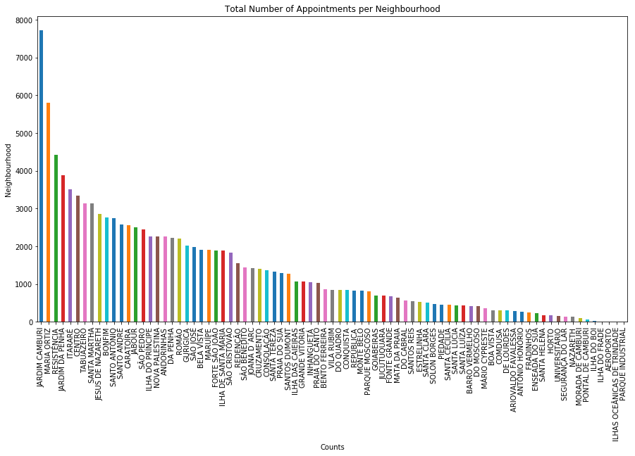

```python
df_a.Neighbourhood.value_counts().plot(kind='bar', figsize=(15,8));
label('Counts','Neighbourhood','Total Number of Appointments per Neighbourhood')
```

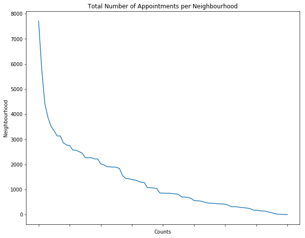

```python
# Line plot to show data
df_a.Neighbourhood.value_counts().plot(kind='line', figsize=(10,8),  title='Total Number of Appointments per Neighbourhood');
label('Counts','Neighbourhood','Total Number of Appointments per Neighbourhood')
```

> **Based on the graph shown above you can easily distinguish which neigbourhood that has the highest count to the lowest number of count.**

### Research Question2: What kind medical condition that had the highest appointment Show up

```python
#  creating a variable of appointment with show up and no show up for each medical condition

#  Diabetes
diabetes_1= df_a[df_a['Diabetes'] == 1]
diabetes_0= df_a[df_a['Diabetes'] == 0]
# andicap
handicap_1= df_a[df_a['Handicap'] == 1]
handicap_0= df_a[df_a['Handicap'] == 0]
# Alcoholism
alcoholism_1= df_a[df_a['Alcoholism'] == 1]
alcoholism_0= df_a[df_a['Alcoholism'] == 0]
# Hypertension
hypertension_1= df_a[df_a['Hypertension'] == 1]
hypertension_0= df_a[df_a['Hypertension'] == 0]
```

```python
female_show_up= df_a[df_a['Gender'] == 'F']
female_show_up.count().sum()
```

```
933920
```

```python
# Diabetes count for show_up and no_show_up
(diabetes_1.shape,diabetes_0.shape)
```

```
((7943, 13), (102584, 13))
```

```python
 # Handicap counts for show_up and no_show_up
(handicap_1.shape,handicap_0.shape)
```

```
((2042, 13), (108286, 13))
```

```python
# Alcoholism count for show_up and no_show_up
(alcoholism_1.shape,alcoholism_0.shape)
```

```
((3360, 13), (107167, 13))
```

```python
# hypertension count for show_up and no_show_up
(hypertension_1.shape,hypertension_0.shape)
```

```
((21801, 13), (88726, 13))
```

```python
#  Creating a new dataframe for the show_up data
reasons = pd.DataFrame({'Condition':['diabetes_show_up','handicap_show_up','alcoholism_show_up','hypertension_show_up'],'Count':[7943,2042,3360,21801]})
```

[figure not shown]

```python
# ploting the findings of show_up on a graph
show_up =  reasons.plot.bar(x='Condition', y='Count', rot=0,  figsize=(18,9) ,color='cornflowerblue')
label('Condition','Count', 'Comparison of conditions Show_up data')
```

[figure not shown]

```python
show_up =  reasons.plot.hist(x='Condition', y='Count',  figsize=(18,9))
label('Condition','Count', 'Comparison of conditions Show_up data')
```

### Research Question3 : What kind medical condition that had the highest appointment No Show up

```python
#  Creating a new dataframe for the no show_up data

reasons2 = pd.DataFrame({'Condition':['diabetes_no_show','handicap_no_show','alcoholism_no_show_up','hypertension_no_show_up'],'Count':[102584,108286,107167,88726]})
```

```python
# Finding the total number of no_show_up of medical condition
diabetes_0.shape,handicap_0.shape,alcoholism_0.shape,hypertension_0.shape
```

```
((102584, 13), (108286, 13), (107167, 13), (88726, 13))
```

[figure not shown]

```python
# ploting the findings of no_show_up on a graph
noshow_up =  reasons2.plot.bar(x='Condition', y='Count', rot=0,
        figsize=(18,9), color='cornflowerblue')
label('Kind of Condition','Counts','Medical Condition that had the highest appointment No show_up')
```

### Research Question4: What gender had the most show up

```python
#  Ceating a variable for those who that showed up for the appointment
show_up = df_a[df_a['No-show']=='No']
Fem = show_up[show_up['Gender']=='F']
Male = show_up[show_up['Gender']=='M']
```

```python
Fem.shape, Male.shape
```

```
((57246, 13), (30962, 13))
```

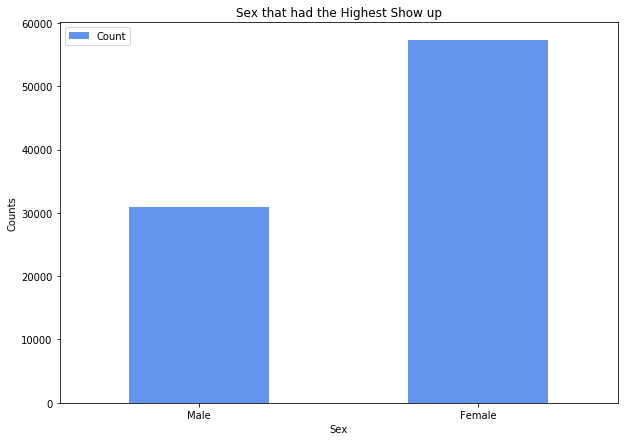

```python
#  Creating a new dataframe for the no show_up data

gender = pd.DataFrame({'Gender':['Male','Female'],'Count':[30962,57246]})
# ploting the findings of no_show_up on a graph
noshow_up = gender.plot.bar(x='Gender', y='Count', rot=0,
        figsize=(10,7), color='cornflowerblue')
label('Sex','Counts', 'Sex that had the Highest Show up')
```

#### Conclusion: From the graph, female were the highest showed up for the appointment more than the male did.